# Demo Analytics con R

17 Enero 2018

## Sobre mí

- Doctor en Ingeniería Matemática
- Especialidad en Estadística
- Investigador en el **Basque Center for Applied Mathematics** http://www.bcamath.org
- Area de *Data Science*
- *Group Leader* en Applied Statistics

## Paradoja

[figure not shown]

## De qué va esta charla …

- Ejemplo práctico de análisis de datos en los que ocurren fenómenos contradictorios.
- Basados en casos reales
- Mostrar cómo hay que usar el sentido común y plantearnos cuestiones que análisis simples o parciales no permiten resolver
- **"Can't see the forest for the trees"**

## Discriminación en la Universidad de Berkeley

- En 1973, la Universidad de California-Berkeley fue demandada por discriminación sexual. Las cifras parecen bastante incriminatorias: las escuelas de graduados acaban de aceptar el 44% de los candidatos hombres, pero sólo el 35% de las candidatas son mujeres.

  | Género | Solicitudes | % Admisión |
  | --- | --- | --- |
  | Hombres | 8442 | 44% |
  | Mujeres | 4321 | 35% |

- Dado que había casi 13.000 solicitantes, una diferencia del 9% en las tasas de admisión entre hombres y mujeres es demasiado grande para ser una coincidencia.

## Discriminación en la Universidad de Berkeley

- Datos agregados sobre los solicitantes para los **6 departamentos** más grandes clasificados por admisión/rechazo y Género (Female/Male).
- **Fuente:** Bickel, P., Hammel, E., & O'Connell, J. (1975). *Sex bias in graduate admissions: data from Berkeley*. **Science**, 187(4175), 398–404.

```r
 library(datasets)
 UCBAdmissions
```

[output not shown]

- Ver visualización en http://vudlab.com/simpsons/
- En %

```
##         Admit
## Gender   Admitted Rejected
##   Male      26.47    32.99
##   Female    12.31    28.24
```

- Consideremos los 6 Departamentos más grandes (A,B,C,D,E,F)

```
##      Gender     Male            Female
##      Admit  Admitted Rejected Admitted Rejected
## Dept
## A                512      313       89       19
## B                353      207       17        8
## C                120      205      202      391
## D                138      279      131      244
## E                 53      138       94      299
## F                 22      351       24      317
```

- Consideremos los 6 Departamentos más grandes (A,B,C,D,E,F) (en %)

```
##      Gender     Male            Female
##      Admit  Admitted Rejected Admitted Rejected
## Dept
## A              62.06    37.94    82.41    17.59
## B              63.04    36.96    68.00    32.00
## C              36.92    63.08    34.06    65.94
## D              33.09    66.91    34.93    65.07
## E              27.75    72.25    23.92    76.08
## F               5.90    94.10     7.04    92.96
```

- ¿Hay ahora sesgo en favor de los hombres?
- **Odds Ratio** (Condicionado al Departamento)
  - es forma de expresar la proporción de veces que un suceso ocurra frente a que no ocurra

```
##           Gender
## Admit      Male Female
##   Admitted  512     89
##   Rejected  313     19
```

`OR` del departamento A (Hombres vs Mujeres)

```r
(512/89)/(313/19)
```

```
## [1] 0.349212
```

- Si `OR > 1` hay sesgo en favor de los hombres frente a las mujeres
- Si `OR < 1` **NO hay sesgo** en favor de los hombres frente a las mujeres
- **OR por departamento**

```
##    A    B    C    D    E    F
## 0.35 0.80 1.13 0.92 1.22 0.83
```

El **OR** de aceptación de hombres es menor que el de las mujeres en los departamentos A, B, D y F.

- Si sólo consideramos el género, ¿cuál es el odds-ratio?

```
##         Admit
## Gender   Admitted Rejected
##   Male       1198     1493
##   Female      557     1278
```

El `OR` es 1.84108

- La dependencia (o asociación) entre el Género y la admisión se puede comprobar estadísticamente mediante el **Test Chi-cuadrado** (\(\chi^2\)), en `R` con la función `chisq.test`

```
##
##  Pearson's Chi-squared test
##
## data:  UCBGbyAdmission
## X-squared = 92.205, df = 1, p-value < 2.2e-16
```

`p-value` es `< 2.2e-16`, por tanto sí hay evidencia (Aquí aparece la paradoja de Simpson!)

- Pero, ¿hay algo más?
- Analicemos las solicitudes por Departamento, Género y Admisión (en %)

```
##         Dept
## Gender       A     B     C     D     E     F
##   Male   30.66 20.81 12.08 15.50  7.10 13.86
##   Female  5.89  1.36 32.32 20.44 21.42 18.58
```

```
##           Dept
## Admit          A     B     C     D     E     F
##   Admitted 64.42 63.25 35.08 33.96 25.17  6.44
##   Rejected 35.58 36.75 64.92 66.04 74.83 93.56
```

- La mayoría de los Hombres solicitan admisión en Dpto. A y B donde la aceptación tiene una tasa mayor, mientras que más Mujeres solicitan admisión a Dpto. C, D, E y F donde la aceptación tiene una tasa menor.
- Gráficamente

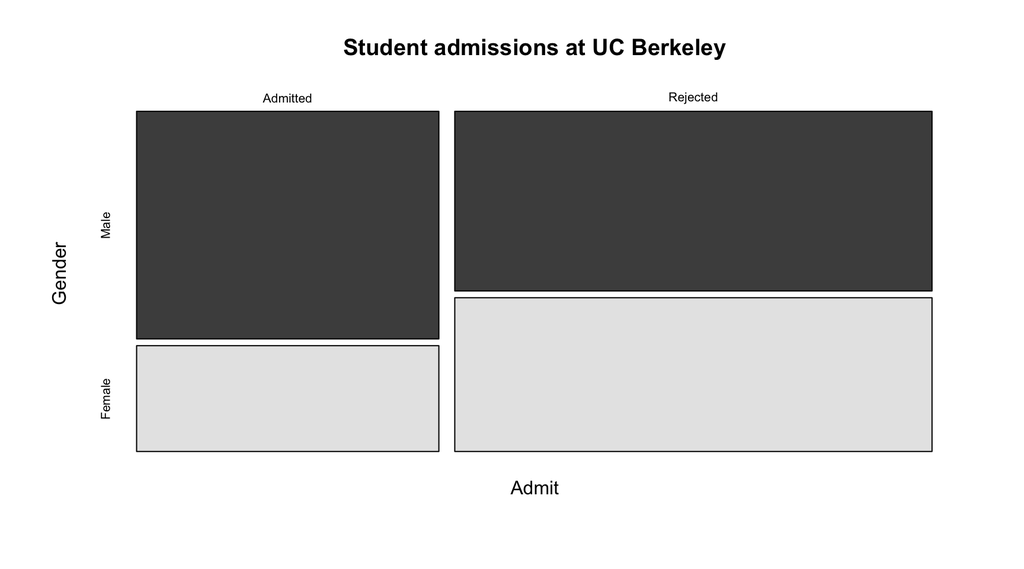

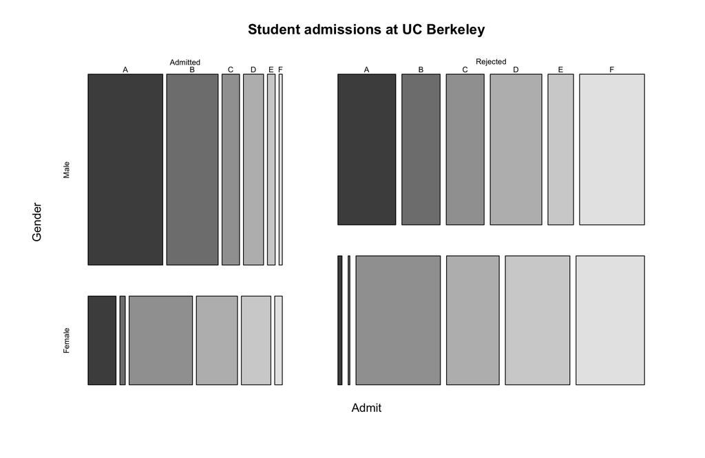

## La paradoja de Simpson (Algebraicamente)

\[ \frac{a}{b} > \frac{c}{d} \quad \mbox{and} \quad \frac{e}{f} > \frac{g}{h} \]

**No implica**

\[ \frac{a+e}{b+f} > \frac{c+g}{d+h} \]

## La paradoja de Simpson en la empresa

- Basado en: *Kievit, R.A., Frankenhuis, W. & Borsboom, D.*. **Simpson's Paradox in Psychological Science: A Practical Guide.** Front Psychol. 2013; 4: 513.
- Supongamos una empresa de 1000 empleados.
- Los empleados han rellenado un test de personalidad (Big Five Personality Test)
- Escala de 0-7 sobre el neuroticismo/inestabilidad emocional en su puesto de trabajo.
- La escala va de 0 (nada neurótico) a 7 (muy neurótico).
- Estamos interesados en la medida en que este neuroticismo de los empleados se relaciona con su Rendimiento Laboral (medido de 0 a 100) y su Salario (medido en Euros por Año).

## Gráfico Rendimiento

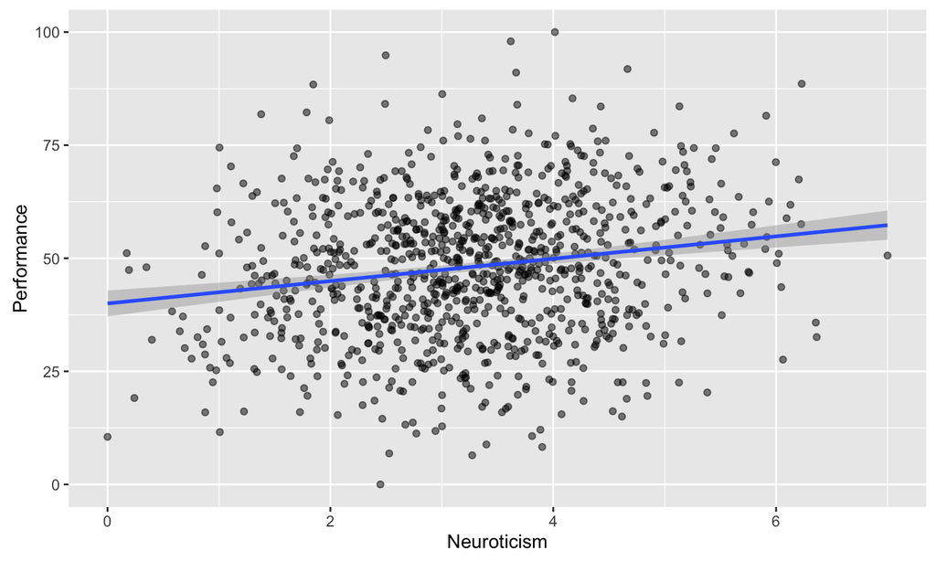

## Gráfico Salario

[figure not shown]

## Neuroticismo VS Salario/Rendimiento

- A partir de estas visualizaciones parecería que el neuroticismo se relaciona de manera significativa y positiva tanto con el rendimiento de los empleados como con su salario anual.
- ¿Debería seleccionar más personas neuróticas para mejorar el rendimiento general de su empresa?
- ¿O está discriminando emocionalmente a los empleados estables (no neuróticos) cuando se trata del salario?

## Gráfico por tipo de trabajo

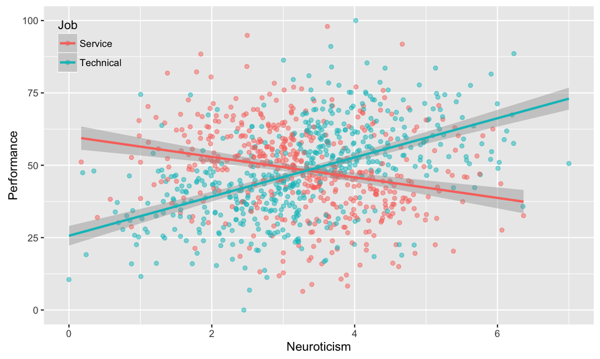

- Mirando más de cerca los subgrupos en sus datos, sin embargo, podría encontrar relaciones muy diferentes.
- Por ejemplo, la relación positiva entre el neuroticismo y el rendimiento sólo se puede aplicar a los puestos técnicos, pero no a aquellos empleados en empleos orientados al servicio.
- Del mismo modo, al dividir a los empleados por nivel de formación, queda claro que existe una relación entre el neuroticismo y el nivel educativo que puede explicar la asociación anterior con el salario.
- Los empleados con mayor nivel educativo reciben salarios más altos y dentro de estos grupos, el neuroticismo está relacionado con menores ingresos anuales.

## Gráfico por Nivel Educativo

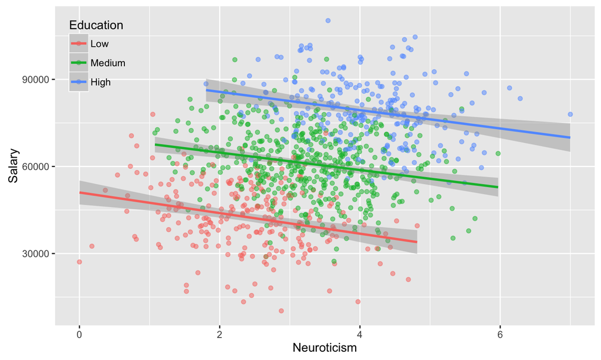

## Algunas conclusiones

- La paradoja de Simpson puede ocurrir en una amplia variedad de diseños, métodos y preguntas de investigación, particularmente dentro de las ciencias sociales y médicas.
- Existen varias maneras para "controlar" o minimizar el riesgo de que ocurra.
- La paradoja puede prevenirse mediante un diseño de investigación más riguroso: mecanismos de prueba en estudios longitudinales o de intervención.
- Sin embargo, esto no siempre es factible.
- Alternativamente, la visualización de datos puede ayudar a reconocer los patrones y subgrupos y por lo tanto diagnosticar las paradojas.

## En `R`

- `library(Simpsons)`
  - **Simpsons: Detecting Simpson's Paradox**

*This package detects instances of Simpson's Paradox in datasets. It examines subpopulations in the data, either user-defined or by means of cluster analysis, to test whether a regression at the level of the group is in the opposite direction at the level of subpopulations.*

## Métodos de Clustering

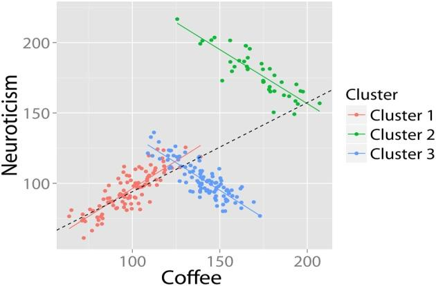